# Atividade_final

Luiza Vieira

31/05/2022

## Informações gerais da atividade

- A atividade teve como objetivo ser uma das etapas iniciais da Modelagem de Distribuição de Especies (MDE).
- Essa etapa inicial foi a limpeza dos dados de ocorrência da espécie e a escolha das variáveis e a limpeza das variáveis importantes para entrar no modelo.
- Utilizei os registros da atividade 3 com a espécie *Chaetodon striatus*.
- Essa atividade será dividida em 3 etapas: Variáveis ambientais, Ocorrência da espécie e Análise de Componentes Principais (PCA)

### Todos os pacotes que foram usados na primeira etapa

```r
library(raster)
library(rgdal)
library(maptools)
library(usdm)
library(CoordinateCleaner)
library(spocc)
library(spThin)
library(dplyr)
library(dismo)
library(corrplot)
```

### 1. Variáveis ambientais

- As variaveis foram obtidas pela base de dados do

  [Bio-Oracle](https://bio-oracle.org/)
- As variáveis são do presente e são de profundidade superficial

```r
Calcite.mean = raster("./Variaveis/Present.Surface.Calcite.Mean.tif") #Concentração média de Calcita
Chlorophyll.mean = raster("./Variaveis/Present.Surface.Chlorophyll.Mean.tif") #Concentração média de clorofila
Chlorophyll.min = raster("./Variaveis/Present.Surface.Chlorophyll.Min.tif") #Concentração mínima de clorofila
Chlorophyll.range = raster("./Variaveis/Present.Surface.Chlorophyll.Range.tif") #Amplitude da concentração de clorofila
Cloud.cover.max = raster("./Variaveis/Present.Surface.Cloud.cover.Max.tif") #Cobertura de nuvens máxima
Cloud.cover.mean = raster("./Variaveis/Present.Surface.Cloud.cover.Mean.tif") #Cobertura de nuvens média
Cloud.cover.min = raster("./Variaveis/Present.Surface.Cloud.cover.Min.tif") #Cobertura de nuvens mínima
C.Velocity.mean = raster("./Variaveis/Present.Surface.Current.Velocity.Mean.tif") #Velocidade de corrente mínima
C.Velocity.min = raster("./Variaveis/Present.Surface.Current.Velocity.Min.tif") #Velocidade de corrente média
C.Velocity.range = raster("./Variaveis/Present.Surface.Current.Velocity.Range.tif") #Amplitude da velocidade de corrente
Diffuse.attenuation.max = raster("./Variaveis/Present.Surface.Diffuse.attenuation.Max.tif") #Atenuação difusa máxima
Diffuse.attenuation.min = raster("./Variaveis/Present.Surface.Diffuse.attenuation.Min.tif") #Atenuação difusa mínima
Dissolved.ox.max = raster("./Variaveis/Present.Surface.Dissolved.oxygen.Max.tif") #Concentração de oxigênio dissolvido máximo
Dissolved.ox.mean = raster("./Variaveis/Present.Surface.Dissolved.oxygen.Mean.tif") #Concentração de oxigênio dissolvido médio
Dissolved.ox.min = raster("./Variaveis/Present.Surface.Dissolved.oxygen.Min.tif") #Concentração de oxigênio dissolvido mínimo
Dissolved.ox.range = raster("./Variaveis/Present.Surface.Dissolved.oxygen.Range.tif") #Amplitude da concentração de oxigênio dissolvido
Iron.mean = raster("./Variaveis/Present.Surface.Iron.Mean.tif") #Concentração de ferro média
Iron.min = raster("./Variaveis/Present.Surface.Iron.Min.tif") #Concentração de ferro mínima
Nitrate.max = raster("./Variaveis/Present.Surface.Nitrate.Max.tif") #Concentração de nitrato máxima
Nitrate.mean = raster("./Variaveis/Present.Surface.Nitrate.Mean.tif") #Concentração de nitrato médio
Nitrate.min = raster("./Variaveis/Present.Surface.Nitrate.Min.tif") #Concentração de nitrato mínimo
Nitrate.range = raster("./Variaveis/Present.Surface.Nitrate.Range.tif") #Amplitude de concentração de nitrato
PAR.max = raster("./Variaveis/Present.Surface.Par.Max.tif") #Radiação fotossinteticamente ativa máxima
PAR.mean = raster("./Variaveis/Present.Surface.Par.Mean.tif") #Radiação fotossinteticamente ativa média
pH = raster("./Variaveis/Present.Surface.pH.tif") #pH
Phosphate.max = raster("./Variaveis/Present.Surface.Phosphate.Max.tif") #Concentração de fosfato máxima
Phosphate.mean = raster("./Variaveis/Present.Surface.Phosphate.Mean.tif") #Concentração de fosfato médio
Phosphate.min = raster("./Variaveis/Present.Surface.Phosphate.Min.tif") #Concentração de fosfato mínimo
Phosphate.range = raster("./Variaveis/Present.Surface.Phosphate.Range.tif") #Amplitude da concentração de fosfato
Phytoplankton.max = raster("./Variaveis/Present.Surface.Phytoplankton.Max.tif") #Concentração de fitoplancton máxima
Phytoplankton.mean = raster("./Variaveis/Present.Surface.Phytoplankton.Mean.tif") #Concentração de fitoplancton média
Phytoplankton.min = raster("./Variaveis/Present.Surface.Phytoplankton.Min.tif") #Concentração de fitoplancton mínima
Phytoplankton.range = raster("./Variaveis/Present.Surface.Phytoplankton.Range.tif") #Amplitude de concentração de fitoplancton
Primary.Productivity.mean = raster("./Variaveis/Present.Surface.Primary.productivity.Mean.tif") #Produtividade primária média
Primary.Productivity.min = raster("./Variaveis/Present.Surface.Primary.productivity.Min.tif") #Produtividade primária mínima
Primary.Productivity.range = raster("./Variaveis/Present.Surface.Primary.productivity.Range.tif") #Amplitude de produtividade primária
Salinity.max = raster("./Variaveis/Present.Surface.Salinity.Max.tif") #Salinidade máxima
Salinity.mean = raster("./Variaveis/Present.Surface.Salinity.Mean.tif") #Salinidade média
Salinity.range = raster("./Variaveis/Present.Surface.Salinity.Range.tif") #Amplitude da salinidade
Salinity.min = raster("./Variaveis/Present.Surface.Salinity.Min.tif") #Salinidade mínima
Silicate.max = raster("./Variaveis/Present.Surface.Silicate.Max.tif") #Concentração de silicato máxima
Silicate.mean = raster("./Variaveis/Present.Surface.Silicate.Mean.tif") #Concentração de silitato média
Silicate.min = raster("./Variaveis/Present.Surface.Silicate.Min.tif") #Concentração de silicato mínima
Temp.max = raster("./Variaveis/Present.Surface.Temperature.Max.tif") #Temperatura máxima
Temp.min = raster("./Variaveis/Present.Surface.Temperature.Min.tif") #Temperatura mínima
Temp.range = raster("./Variaveis/Present.Surface.Temperature.Range.tif") #Amplitude da temperatura
Temp.mean = raster("./Variaveis/Present.Surface.Temperature.Mean.tif") #Temperatura média
```

- Depois disso, foi preciso limitar a extensão que foi utilizada para a atividade de acordo com a ocorrência da espécie

```r
atlantic.ext <- extent(-100, 0, -40, 40)
```

- Polígono das Ecorregiões do Western Atlantic

```r
ecoreg <- readOGR("./Ecorregion/Atlantico_EUA_Brazil/Shape_Stega_Atlantico_EUA_Brazil.shp")
```

- Cortar as variáveis de acordo com os limites do polígono

```r
Calcite.mean.ecoreg <- mask(crop(Calcite.mean, atlantic.ext), ecoreg)
Chlorophyll.mean.ecoreg <- mask(crop(Chlorophyll.mean, atlantic.ext), ecoreg)
Chlorophyll.min.ecoreg <- mask(crop(Chlorophyll.min, atlantic.ext), ecoreg)
Chlorophyll.range.ecoreg <- mask(crop(Chlorophyll.range, atlantic.ext), ecoreg)
Cloud.cover.max.ecoreg <- mask(crop(Cloud.cover.max, atlantic.ext), ecoreg)
Cloud.cover.mean.ecoreg <- mask(crop(Cloud.cover.mean, atlantic.ext), ecoreg)
Cloud.cover.min.ecoreg <- mask(crop(Cloud.cover.min, atlantic.ext), ecoreg)
C.Velocity.mean.ecoreg <- mask(crop(C.Velocity.mean, atlantic.ext), ecoreg)
C.Velocity.min.ecoreg <- mask(crop(C.Velocity.min, atlantic.ext), ecoreg)
C.Velocity.range.ecoreg <- mask(crop(C.Velocity.range, atlantic.ext), ecoreg)
Diffuse.attenuation.max.ecoreg <- mask(crop(Diffuse.attenuation.max, atlantic.ext), ecoreg)
Diffuse.attenuation.min.ecoreg <- mask(crop(Diffuse.attenuation.min, atlantic.ext), ecoreg)
Dissolved.ox.max.ecoreg <- mask(crop(Dissolved.ox.max, atlantic.ext), ecoreg)
Dissolved.ox.mean.ecoreg <- mask(crop(Dissolved.ox.mean, atlantic.ext), ecoreg)
Dissolved.ox.min.ecoreg <- mask(crop(Dissolved.ox.min, atlantic.ext), ecoreg)
Dissolved.ox.range.ecoreg <- mask(crop(Dissolved.ox.range, atlantic.ext), ecoreg)
Iron.mean.ecoreg <- mask(crop(Iron.mean, atlantic.ext), ecoreg)
Iron.min.ecoreg <- mask(crop(Iron.min, atlantic.ext), ecoreg)
Nitrate.max.ecoreg <- mask(crop(Nitrate.max, atlantic.ext), ecoreg)
Nitrate.mean.ecoreg <- mask(crop(Nitrate.mean, atlantic.ext), ecoreg)
Nitrate.min.ecoreg <- mask(crop(Nitrate.min, atlantic.ext), ecoreg)
Nitrate.range.ecoreg <- mask(crop(Nitrate.range, atlantic.ext), ecoreg)
PAR.max.ecoreg <- mask(crop(PAR.max, atlantic.ext), ecoreg)
PAR.mean.ecoreg <- mask(crop(PAR.mean, atlantic.ext), ecoreg)
pH.ecoreg <- mask(crop(pH, atlantic.ext), ecoreg)
Phosphate.max.ecoreg <- mask(crop(Phosphate.max, atlantic.ext), ecoreg)
Phosphate.mean.ecoreg <- mask(crop(Phosphate.mean, atlantic.ext), ecoreg)
Phosphate.min.ecoreg <- mask(crop(Phosphate.min, atlantic.ext), ecoreg)
Phosphate.range.ecoreg <- mask(crop(Phosphate.range, atlantic.ext), ecoreg)
Phytoplankton.max.ecoreg <- mask(crop(Phytoplankton.max, atlantic.ext), ecoreg)
Phytoplankton.mean.ecoreg <- mask(crop(Phytoplankton.mean, atlantic.ext), ecoreg)
Phytoplankton.min.ecoreg <- mask(crop(Phytoplankton.min, atlantic.ext), ecoreg)
Phytoplankton.range.ecoreg <- mask(crop(Phytoplankton.range, atlantic.ext), ecoreg)
Primary.Productivity.mean.ecoreg <- mask(crop(Primary.Productivity.mean, atlantic.ext), ecoreg)
Primary.Productivity.min.ecoreg <- mask(crop(Primary.Productivity.min, atlantic.ext), ecoreg)
Primary.Productivity.range.ecoreg <- mask(crop(Primary.Productivity.range, atlantic.ext), ecoreg)
Salinity.max.ecoreg <- mask(crop(Salinity.max, atlantic.ext), ecoreg)
Salinity.mean.ecoreg <- mask(crop(Salinity.mean, atlantic.ext), ecoreg)
Salinity.range.ecoreg <- mask(crop(Salinity.range, atlantic.ext), ecoreg)
Salinity.min.ecoreg <- mask(crop(Salinity.min, atlantic.ext), ecoreg)
Silicate.max.ecoreg <- mask(crop(Silicate.max, atlantic.ext), ecoreg)
Silicate.mean.ecoreg <- mask(crop(Silicate.mean, atlantic.ext), ecoreg)
Silicate.min.ecoreg <- mask(crop(Silicate.min, atlantic.ext), ecoreg)
Temp.max.ecoreg <- mask(crop(Temp.max, atlantic.ext), ecoreg)
Temp.min.ecoreg <- mask(crop(Temp.min, atlantic.ext), ecoreg)
Temp.range.ecoreg <- mask(crop(Temp.range, atlantic.ext), ecoreg)
Temp.mean.ecoreg <- mask(crop(Temp.mean, atlantic.ext), ecoreg)
```

- Comparar as camadas para ver se estão todas no mesmo formato

```r
compareRaster(Temp.mean.ecoreg, Temp.range.ecoreg, Temp.min.ecoreg, Temp.max.ecoreg, Silicate.min.ecoreg, Silicate.mean.ecoreg, Silicate.max.ecoreg, Salinity.min.ecoreg, Salinity.range.ecoreg, Salinity.mean.ecoreg, Salinity.max.ecoreg, Primary.Productivity.range.ecoreg, Primary.Productivity.min.ecoreg, Primary.Productivity.mean.ecoreg, Phytoplankton.range.ecoreg, Phytoplankton.min.ecoreg, Primary.Productivity.mean.ecoreg, Phytoplankton.max.ecoreg, Phosphate.range.ecoreg, Phosphate.min.ecoreg, Phosphate.mean.ecoreg, Phosphate.max.ecoreg, pH.ecoreg, PAR.mean.ecoreg, PAR.max.ecoreg, Nitrate.range.ecoreg, Nitrate.min.ecoreg, Nitrate.mean.ecoreg, Nitrate.max.ecoreg, Iron.min.ecoreg, Iron.mean.ecoreg, Dissolved.ox.range.ecoreg, Dissolved.ox.min.ecoreg, Dissolved.ox.mean.ecoreg, Dissolved.ox.max.ecoreg, Diffuse.attenuation.min.ecoreg, Diffuse.attenuation.max.ecoreg, C.Velocity.range.ecoreg, C.Velocity.min.ecoreg, C.Velocity.mean.ecoreg, Calcite.mean.ecoreg, Chlorophyll.mean.ecoreg, Chlorophyll.min.ecoreg, Chlorophyll.range.ecoreg, Cloud.cover.max.ecoreg, Cloud.cover.mean.ecoreg, Cloud.cover.min.ecoreg)
```

```
## [1] TRUE
```

- Criar um stack com todas as variáveis

```r
Variaveis_1 <- stack(Temp.mean.ecoreg, Temp.range.ecoreg, Temp.min.ecoreg, Temp.max.ecoreg, Silicate.min.ecoreg, Silicate.mean.ecoreg, Silicate.max.ecoreg, Salinity.min.ecoreg, Salinity.range.ecoreg, Salinity.mean.ecoreg, Salinity.max.ecoreg, Primary.Productivity.range.ecoreg, Primary.Productivity.min.ecoreg, Primary.Productivity.mean.ecoreg, Phytoplankton.range.ecoreg, Phytoplankton.min.ecoreg, Primary.Productivity.mean.ecoreg, Phytoplankton.max.ecoreg, Phosphate.range.ecoreg, Phosphate.min.ecoreg, Phosphate.mean.ecoreg, Phosphate.max.ecoreg, pH.ecoreg, PAR.mean.ecoreg, PAR.max.ecoreg, Nitrate.range.ecoreg, Nitrate.min.ecoreg, Nitrate.mean.ecoreg, Nitrate.max.ecoreg, Iron.min.ecoreg, Iron.mean.ecoreg, Dissolved.ox.range.ecoreg, Dissolved.ox.min.ecoreg, Dissolved.ox.mean.ecoreg, Dissolved.ox.max.ecoreg, Diffuse.attenuation.min.ecoreg, Diffuse.attenuation.max.ecoreg, C.Velocity.range.ecoreg, C.Velocity.min.ecoreg, C.Velocity.mean.ecoreg, Calcite.mean.ecoreg, Chlorophyll.mean.ecoreg, Chlorophyll.min.ecoreg, Chlorophyll.range.ecoreg, Cloud.cover.max.ecoreg, Cloud.cover.mean.ecoreg, Cloud.cover.min.ecoreg)
```

- Serve para se poder reproduzir os resultados dos geradores de números pseudo-aleatórios

```r
set.seed(1963)
```

- Verificar se as variáveis são colineares por meio do fator de inflação da variância (VIF) vircor (threshold = 0.7)

  ```r
  vifcor(Variaveis_1,th = 0.7)
  ```

  ```
  ## 31 variables from the 47 input variables have collinearity problem:
  ##
  ## Present.Surface.Primary.productivity.Mean.2 Present.Surface.Phytoplankton.Max Present.Surface.Dissolved.oxygen.Max Present.Surface.Chlorophyll.Range Present.Surface.Iron.Min Present.Surface.Chlorophyll.Min Present.Surface.Nitrate.Max Present.Surface.Temperature.Min Present.Surface.Phosphate.Max P…
  ##
  ## After excluding the collinear variables, the linear correlation coefficients ranges between:
  ## min correlation ( Present.Surface.Cloud.cover.Min ~ Present.Surface.pH ):  0.007653135
  ## max correlation ( Present.Surface.Primary.productivity.Min ~ Present.Surface.Salinity.Range ):  0.6802665
  ##
  ## ---------- VIFs of the remained variables --------
  ##                                     Variables      VIF
  ## 1                Present.Surface.Silicate.Min 3.478535
  ## 2              Present.Surface.Salinity.Range 3.719835
  ## 3  Present.Surface.Primary.productivity.Range 3.099625
  ## 4    Present.Surface.Primary.productivity.Min 4.243423
  ## 5             Present.Surface.Phosphate.Range 3.105098
  ## 6               Present.Surface.Phosphate.Min 2.882240
  ## 7                          Present.Surface.pH 2.819555
  ## 8                    Present.Surface.Par.Mean 2.219106
  ## 9                     Present.Surface.Par.Max 2.061098
  ## 10              Present.Surface.Nitrate.Range 3.437801
  ## 11                Present.Surface.Nitrate.Min 2.643907
  ## 12     Present.Surface.Current.Velocity.Range 1.920487
  ## 13       Present.Surface.Current.Velocity.Min 1.501963
  ## 14               Present.Surface.Calcite.Mean 2.267807
  ## 15            Present.Surface.Cloud.cover.Max 2.297442
  ## 16            Present.Surface.Cloud.cover.Min 2.168012
  ```

  virstep (threshold = 10)

  ```r
  vifstep(Variaveis_1, th = 10)
  ```

  ```
  ## 26 variables from the 47 input variables have collinearity problem:
  ##
  ## Present.Surface.Primary.productivity.Mean.1 Present.Surface.Dissolved.oxygen.Max Present.Surface.Temperature.Min Present.Surface.Salinity.Min Present.Surface.Nitrate.Max Present.Surface.Phytoplankton.Max Present.Surface.Phosphate.Max Present.Surface.Temperature.Mean Present.Surface.Silicate.Mean …
  ##
  ## After excluding the collinear variables, the linear correlation coefficients ranges between:
  ## min correlation ( Present.Surface.Current.Velocity.Min ~ Present.Surface.Diffuse.attenuation.Max ):  0.0008189766
  ## max correlation ( Present.Surface.Phosphate.Range ~ Present.Surface.Temperature.Max ):  -0.8074295
  ##
  ## ---------- VIFs of the remained variables --------
  ##                                     Variables      VIF
  ## 1           Present.Surface.Temperature.Range 6.794141
  ## 2             Present.Surface.Temperature.Max 7.496361
  ## 3                Present.Surface.Silicate.Min 4.635260
  ## 4              Present.Surface.Salinity.Range 4.124886
  ## 5                Present.Surface.Salinity.Max 3.813576
  ```

  [output cut: 16 more lines]

- A partir dessa analise, foram ser excluídas as variáveis com multicolinearidade
- Foi escolhido o valor de corte do vifstep

```r
Variaveis_2 <- vifstep(Variaveis_1, th = 10)

Variaveis_2 <- exclude(Variaveis_1, Variaveis_2)
vifstep(Variaveis_1, th = 10)
```

### Todos os pacotes que foram usados na segunda etapa

```r
library(rgbif)
library(robis)
library(tidyverse)
library(ggmap)
library(maps)
```

### 2. Ocorrências da espécie *Chaetodon striatus*

- Baixar as ocorrências da espécie por meio da base de dados

  [GBIF](https://www.gbif.org/)

```r
p_borboleta <- occ_data(scientificName = "Chaetodon striatus",
                      hasCoordinate = TRUE,
                      hasGeospatialIssue=FALSE)
```

- Checar número de linhas, colunas e os nomes das colunas. Foi atribuído também os dados ao objeto

```r
dim(p_borboleta$data)
```

```
## [1] 500 123
```

```r
p_borboleta$data %>% names

p_borboleta <- p_borboleta$data
```

- Checar os possíveis erros

```r
gbif_issues()
```

```r
issues_gbif <- p_borboleta$issues %>%
  unique()
gbif_issues() %>%
  data.frame() %>%
  filter(code %in% issues_gbif)
```

```
##      code                                            issue
## 1 cdround                               COORDINATE_ROUNDED
## 2    cudc                 COUNTRY_DERIVED_FROM_COORDINATES
## 3   osiic OCCURRENCE_STATUS_INFERRED_FROM_INDIVIDUAL_COUNT
##                                                                                 description
## 1                                   Original coordinate modified by rounding to 5 decimals.
## 2 The interpreted country is based on the coordinates, not the verbatim string information.
## 3                            Occurrence status was inferred from the individual count value
##         type
## 1 occurrence
## 2 occurrence
## 3 occurrence
```

- Selecionar e investigar as variáveis

```r
p_borboleta_1 <- p_borboleta %>%
  dplyr::select(scientificName, decimalLatitude, decimalLongitude) %>%
  distinct()

lapply(p_borboleta_1, unique)
```

- Usando agora o CoordinateCleaner para limpar as variáveis

```r
flags_spatial_gbif <- CoordinateCleaner::clean_coordinates(
  x = p_borboleta_1,
  species = "scientificName",
  lon = "decimalLongitude",
  lat = "decimalLatitude",
  tests = c("capitals", # raio ao redor de capitais
            "centroids", # raio ao redor de centroides de países e províncias
            "duplicates", # duplicatas
            "equal", # coordenadas iguais
            "gbif", # raio ao redor da sede da GBIF
            "institutions", # raio ao redor de instituicoes de pesquisa em biodiversidade
            "urban", # pontos dentro de areas urbanas
            "validity", # ponto de fora do sistema de coordenadas
            "zeros" # zeros e pontos onde lat = lon
  )
)
```

```
## Testing coordinate validity
```

```
## Flagged 0 records.
```

```
## Testing equal lat/lon
```

```
## Flagged 0 records.
```

```
## Testing zero coordinates
```

```
## Flagged 0 records.
```

```
## Testing country capitals
```

```
## Flagged 15 records.
```

```
## Testing country centroids
```

```
## Flagged 3 records.
```

```
## Testing urban areas
```

```
## Flagged 3 records.
```

```
## Testing GBIF headquarters, flagging records around Copenhagen
```

```
## Flagged 0 records.
```

```
## Testing biodiversity institutions
```

```
## Flagged 0 records.
```

```
## Testing duplicates
```

```
## Flagged 0 records.
```

```
## Flagged 16 of 313 records, EQ = 0.05.
```

```r
p_borboleta_1 <- p_borboleta_1 %>%
  dplyr::filter(flags_spatial_gbif$.summary == TRUE)
```

- Plotar

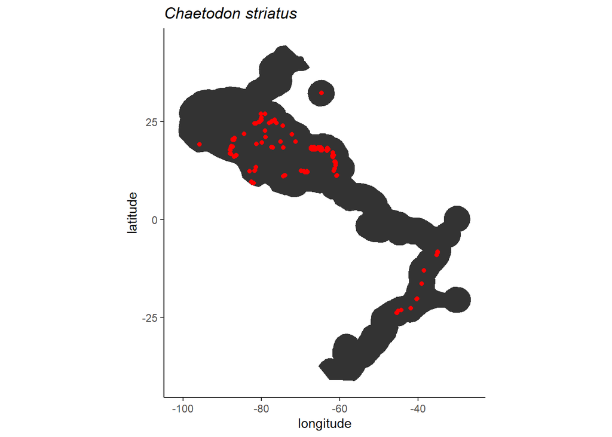

```r
ggplot() +
  geom_polygon(data = ecoreg, aes(x = long, y = lat, group = group)) +
  coord_fixed() +
  theme_classic() +
  geom_point(data = p_borboleta_1, aes(x = decimalLongitude, y = decimalLatitude), color = "red") +
  labs(x = "longitude", y = "latitude", title = expression(italic("Chaetodon striatus")))
```

- Baixar as ocorrências da espécie por meio da base de dados

  [OBIS](https://obis.org/)

```r
p_borboleta_obis <- robis::occurrence("Chaetodon striatus")

names(p_borboleta_obis)
```

- Selecionar as colunas e registros únicos para fazer a limpeza

```r
p_borboleta_obis_1 <- p_borboleta_obis %>%
  dplyr::select(scientificName, decimalLatitude, decimalLongitude, bathymetry,
                flags, waterBody, basisOfRecord, occurrenceStatus, rightsHolder,
                datasetName, recordedBy, depth, locality, habitat) %>%
  distinct()
```

- Checar os problemas reportados

```r
p_borboleta_obis_1 %>%
  distinct(flags)
```

```
## # A tibble: 8 x 1
##   flags
##   <chr>
## 1 <NA>
## 2 NO_DEPTH
## 3 ON_LAND
## 4 NO_DEPTH,ON_LAND
## 5 DEPTH_EXCEEDS_BATH
## 6 ON_LAND,DEPTH_EXCEEDS_BATH
## 7 ON_LAND,NO_DEPTH
## 8 DEPTH_EXCEEDS_BATH,ON_LAND
```

- Retirar os problemas reportados e verificar as demais variáveis

```r
p_borboleta_obis_1 %>%
  filter(!flags %in% c("on_land,no_depth","no_depth,on_land", "on_land", "on_land,depth_exceeds_bath", "depth_exceeds_bath,on_land", "no depth", "na", "depth_exceeds_bath"),
         !is.na(datasetName)) %>%
  lapply(., unique)
```

- Limpar os dados pelo CoordinateCleaner

```r
flags_spatial_obis <- CoordinateCleaner::clean_coordinates(
  x = p_borboleta_obis_1,
  species = "scientificName",
  lon = "decimalLongitude",
  lat = "decimalLatitude",
  tests = c("capitals", # raio ao redor de capitais
            "centroids", # raio ao redor de centroides de paises e provincias
            "duplicates", # duplicatas
            "equal", # coordenadas iguais
            "gbif", # raio ao redor da sede da GBIF
            "institutions", # raio ao redor de instituicoes de pesquisa em biodiversidade
            "urban", # pontos dentro de areas urbanas
            "validity", # ponto de fora do sistema de coordenadas
            "zeros" # zeros e pontos onde lat = lon
  )
)
```

```
## Testing coordinate validity
```

```
## Flagged 0 records.
```

```
## Testing equal lat/lon
```

```
## Flagged 0 records.
```

```
## Testing zero coordinates
```

```
## Flagged 0 records.
```

```
## Testing country capitals
```

```
## Flagged 60 records.
```

```
## Testing country centroids
```

```
## Flagged 5 records.
```

```
## Testing urban areas
```

```
## Flagged 5 records.
```

```
## Testing GBIF headquarters, flagging records around Copenhagen
```

```
## Flagged 0 records.
```

```
## Testing biodiversity institutions
```

```
## Flagged 0 records.
```

```
## Testing duplicates
```

```
## Flagged 647 records.
```

```
## Flagged 709 of 3851 records, EQ = 0.18.
```

```r
p_borboleta_obis_1 <- p_borboleta_obis_1 %>%
  dplyr::filter(flags_spatial_obis$.summary == TRUE)
```

- Selecionar apenas as variáveis de interesse (apenas as coordenadas)

```r
p_borboleta_obis_1 <- p_borboleta_obis %>%
  dplyr::select(scientificName, decimalLatitude, decimalLongitude) %>%
  distinct()
```

- Plotar no polígono

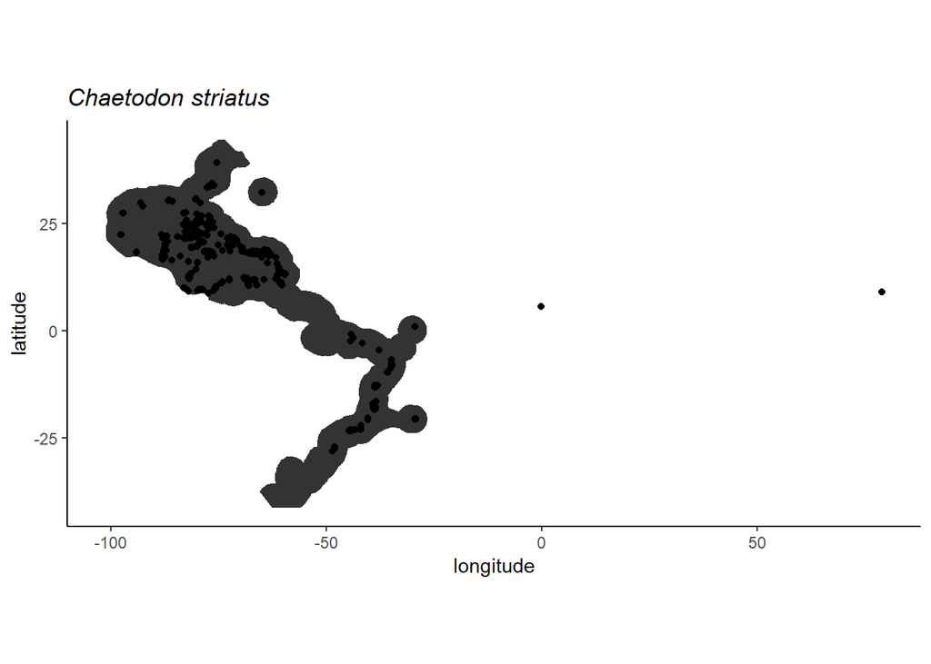

```r
ggplot() +
  geom_polygon(data = ecoreg, aes(x = long, y = lat, group = group)) +
  coord_fixed() +
  theme_classic() +
  geom_point(data = p_borboleta_obis_1, aes(x = decimalLongitude, y = decimalLatitude)) +
  labs(x = "longitude", y = "latitude", title = expression(italic("Chaetodon striatus")))
```

### Juntar os dados do **GBIF** com o do **OBIS**

```r
all_data <- bind_rows(p_borboleta_1 %>%
                        mutate(repo = paste0("gbif", row.names(.))),
                      p_borboleta_obis_1 %>%
                        mutate(repo = paste0("obis", row.names(.)))) %>%
  column_to_rownames("repo") %>%
  dplyr::select(decimalLongitude, decimalLatitude) %>%
  distinct() %>%
  rownames_to_column("occ") %>%
  separate(col = "occ", into = c("datasetName", "rn"), sep = 4) %>%
  mutate(scientificName = "Chaetodon striatus") %>%
  dplyr::select(-rn)

all_data
```

- spthin para ajustar a correlação espacial
- Foi criado o diretório thinned

```r
dir.create("./thinned")
```

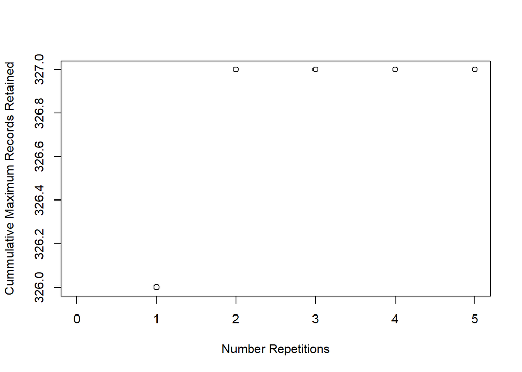

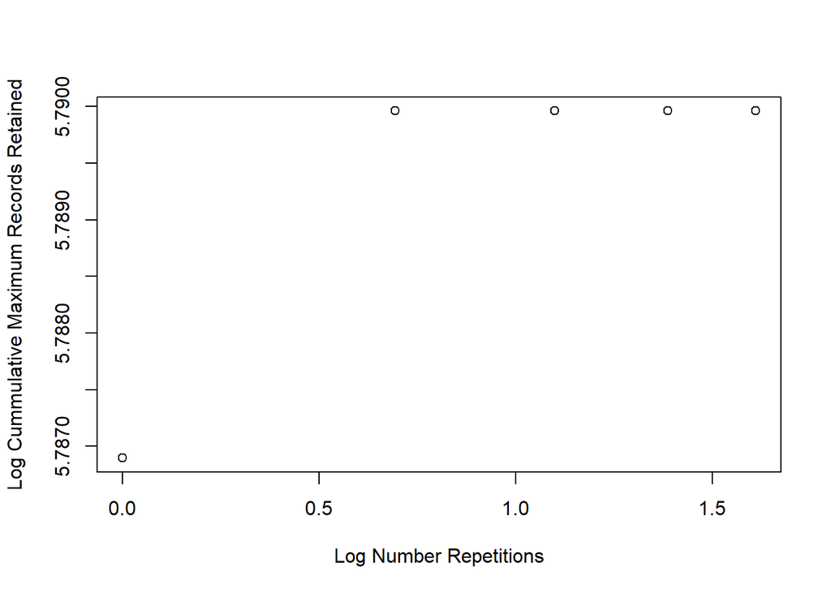

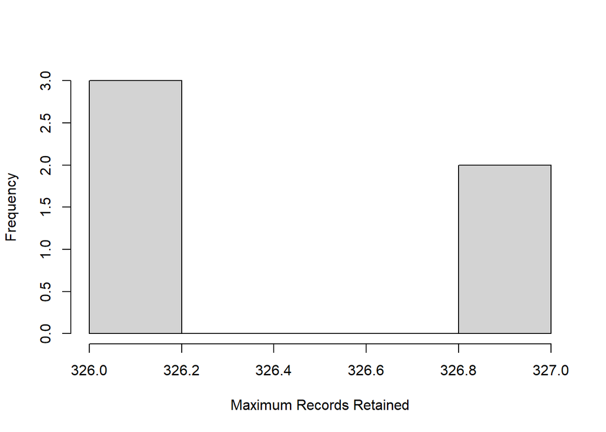

```r
all_data_thin <-
  thin( loc.data = all_data,
        lat.col = "decimalLatitude", long.col = "decimalLongitude",
        spec.col = "scientificName",
        thin.par = 20 #distancia em km que os registros vao ficar separados#
        ,reps = 5,
        locs.thinned.list.return = TRUE,
        write.files = TRUE,
        max.files = 2,
        out.dir = "./thinned", out.base = "p_borboleta_thinned",
        write.log.file = TRUE,
        log.file = "./thinned/p_borboleta_thinned_log.txt")

plotThin(all_data_thin)
```

- Salvar o csv

```r
all_data_thin = read.csv("./thinned/p_borboleta_thinned_thin1.csv", sep=",")
View(all_data_thin)
```

- Limpar os registros fora do Western Atlantic

```r
c(all_data_thin$decimalLongitude)

print(all_data_thin)

all_data_thin_r <- all_data_thin[-c(127, 259),]
```

- Mapa com todas as ocorrências

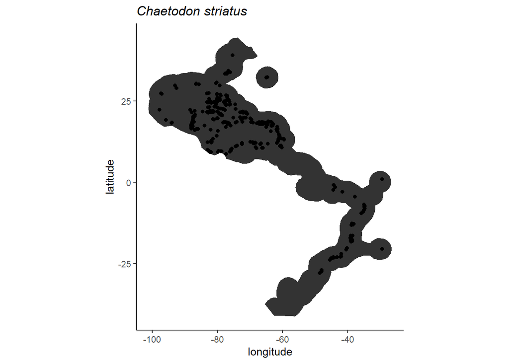

```r
ggplot() +
  geom_polygon(data = ecoreg, aes(x = long, y = lat, group = group)) +
  coord_fixed() +
  theme_classic() +
  geom_point(data = all_data_thin_r, aes(x = decimalLongitude, y = decimalLatitude)) +
  #theme(legend.title = element_blank()) +
  labs(x = "longitude", y = "latitude", title = expression(italic("Chaetodon striatus")))
```

```r
write.csv(all_data, "occ_GBIF-OBIS_par_hepa.csv", row.names = FALSE)
```

### Todos os pacotes que foram usados na terceira etapa

```r
library(sp)
library(rgdal)
library(ggplot2)
library(devtools)
library(ggbiplot)
```

### 3. PCA

- Transformar em dados espaciais

```r
coordinates(all_data_thin_r) <- ~ decimalLongitude+decimalLatitude
class(all_data_thin_r)
```

- Plotar os dados espaciais

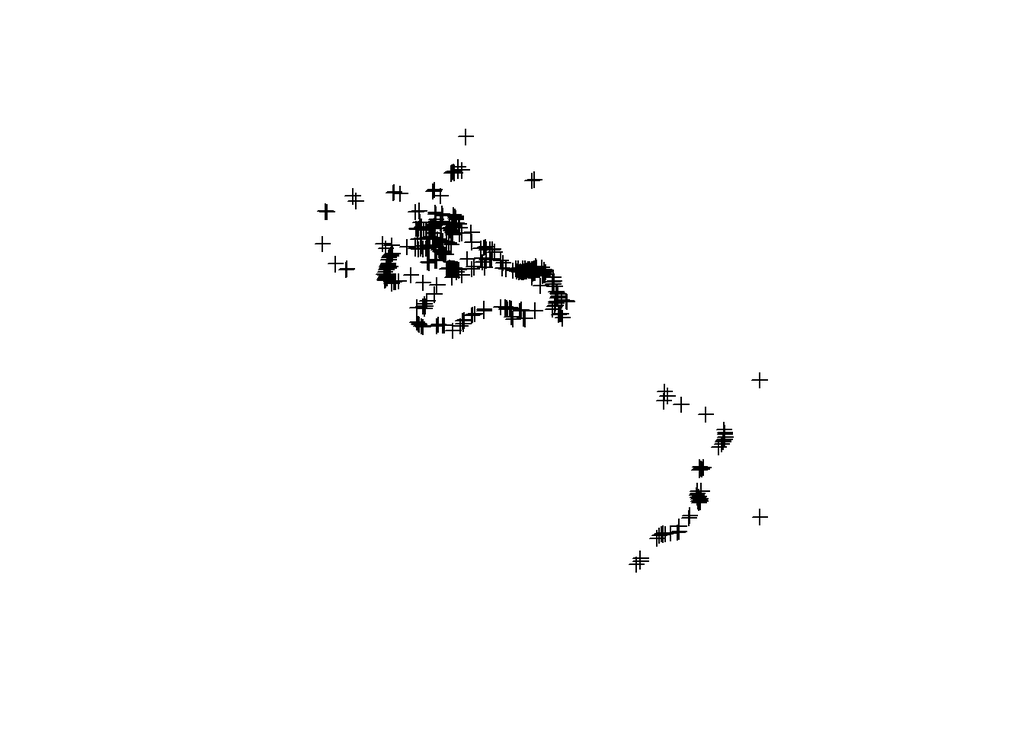

```r
plot(all_data_thin_r)
```

- Verificando se todas as informações do dataframe estão corretas e preenchidas

```r
all_data_thin_r

proj4string (all_data_thin_r) <- CRS("+proj=longlat +datum=WGS84 +no_defs")
```

```r
valores_var_Chaetodonstriatus <- data.frame(raster::extract(Variaveis_2, all_data_thin_r))
View(valores_var_Chaetodonstriatus)

c(valores_var_Chaetodonstriatus)
```

- Tirar os valores NA do conjunto de dados

```r
valores_semNA = valores_var_Chaetodonstriatus %>% tidyr::drop_na(Present.Surface.Temperature.Range, Present.Surface.Temperature.Max, Present.Surface.Silicate.Min, Present.Surface.Salinity.Range, Present.Surface.Nitrate.Range, Present.Surface.Par.Max, Present.Surface.Par.Mean, Present.Surface.pH, Present.Surface.Phosphate.Min, Present.Surface.Phosphate.Range, Present.Surface.Primary.productivity.Min, Present.Surface.Primary.productivity.Range, Present.Surface.Salinity.Max, Present.Surface.Nitrate.Min, Present.Surface.Iron.Mean, Present.Surface.Diffuse.attenuation.Max, Present.Surface.Current.Velocity.Range, Present.Surface.Current.Velocity.Min, Present.Surface.Calcite.Mean, Present.Surface.Cloud.cover.Max, Present.Surface.Cloud.cover.Min)
```

- Rodando o PCA

```r
PCA_1 = prcomp(valores_semNA, center = TRUE, scale. = TRUE)
PCA_1
```

```
## Standard deviations (1, .., p=22):
##  [1] 2.2551921 2.0361401 1.6249525 1.3499852 1.2111444 1.0808774 1.0103792
##  [8] 0.8315915 0.8099642 0.7598444 0.6852070 0.6559987 0.6198269 0.5843056
## [15] 0.5099994 0.4981850 0.4279798 0.3721388 0.3251856 0.2865223 0.2106531
## [22] 0.1916512
##
## Rotation (n x k) = (22 x 22):
##                                                     PC1         PC2         PC3
## Present.Surface.Temperature.Range           0.172151829  0.23390027 -0.25985073
## Present.Surface.Temperature.Max            -0.279062855  0.26883502  0.01833801
## Present.Surface.Silicate.Min               -0.050766192  0.42359837  0.17576065
## Present.Surface.Salinity.Range              0.175560782  0.22346789  0.13974712
## Present.Surface.Salinity.Max               -0.002956739 -0.31954652 -0.24619770
## Present.Surface.Primary.productivity.Range  0.363117464 -0.04599362  0.02246710
## Present.Surface.Primary.productivity.Min    0.343678564 -0.02115418 -0.01395124
## Present.Surface.Phytoplankton.Min           0.396578753 -0.13430075 -0.04166313
## Present.Surface.Phosphate.Range             0.316382329 -0.15918656 -0.06146512
## Present.Surface.Phosphate.Min               0.246674486 -0.24930021 -0.10234329
## Present.Surface.pH                         -0.235080411  0.02506819 -0.30776224
## Present.Surface.Par.Mean                   -0.149332037 -0.09381132 -0.07334397
## Present.Surface.Par.Max                    -0.033877527 -0.06330863 -0.37736974
## Present.Surface.Nitrate.Range               0.208394473  0.34325386 -0.08376683
## Present.Surface.Nitrate.Min                 0.140841371  0.35683334 -0.03445757
## Present.Surface.Iron.Mean                   0.095274322  0.36139463 -0.09072590
## Present.Surface.Diffuse.attenuation.Max     0.314287659  0.14867846 -0.11104899
## Present.Surface.Current.Velocity.Range     -0.055357327 -0.06152981  0.37251032
## Present.Surface.Current.Velocity.Min       -0.013568433 -0.06228211  0.29255499
## Present.Surface.Calcite.Mean                0.067390839  0.04664097 -0.13797501
## Present.Surface.Cloud.cover.Max             0.162287902 -0.04250412  0.40159717
## Present.Surface.Cloud.cover.Min             0.083268563 -0.10244925  0.35843790
##                                                    PC4          PC5         PC6
## Present.Surface.Temperature.Range           0.31448215 -0.329054065  0.13244447
## Present.Surface.Temperature.Max            -0.09707366  0.042198679  0.16405242
## Present.Surface.Silicate.Min               -0.06613851  0.001762159 -0.12816562
## Present.Surface.Salinity.Range             -0.36774268  0.182486347 -0.10112410
## Present.Surface.Salinity.Max                0.08736628  0.194203938  0.28663129
## Present.Surface.Primary.productivity.Range -0.12877495 -0.139783190 -0.01143936
## Present.Surface.Primary.productivity.Min   -0.21470444 -0.018296906 -0.08870214
## Present.Surface.Phytoplankton.Min          -0.12255203  0.015200225  0.03959683
## Present.Surface.Phosphate.Range            -0.10627514 -0.175967659 -0.08662640
```

[output cut: 159 more lines]

```
## Present.Surface.Phytoplankton.Min          -0.66986416  0.25900049
## Present.Surface.Phosphate.Range            -0.21482887 -0.12210717
## Present.Surface.Phosphate.Min               0.12720646 -0.08438838
## Present.Surface.pH                         -0.07414771  0.08894567
## Present.Surface.Par.Mean                    0.17807005 -0.38421129
## Present.Surface.Par.Max                     0.02913449  0.17491003
## Present.Surface.Nitrate.Range               0.20773907  0.32331283
## Present.Surface.Nitrate.Min                -0.02202206 -0.03528079
## Present.Surface.Iron.Mean                   0.12578975  0.06320924
## Present.Surface.Diffuse.attenuation.Max     0.08518378 -0.02625172
## Present.Surface.Current.Velocity.Range     -0.00689762 -0.04969620
## Present.Surface.Current.Velocity.Min        0.03484215 -0.01306889
## Present.Surface.Calcite.Mean                0.01281307 -0.01428465
## Present.Surface.Cloud.cover.Max            -0.07705829 -0.03016295
## Present.Surface.Cloud.cover.Min             0.13695158 -0.03305027
```

```r
attributes(PCA_1)
```

```
## $names
## [1] "sdev"     "rotation" "center"   "scale"    "x"
##
## $class
## [1] "prcomp"
```

```r
summary(PCA_1)
```

```
## Importance of components:
##                           PC1    PC2    PC3     PC4     PC5    PC6    PC7
## Standard deviation     2.2552 2.0361 1.6250 1.34999 1.21114 1.0809 1.0104
## Proportion of Variance 0.2312 0.1885 0.1200 0.08284 0.06668 0.0531 0.0464
## Cumulative Proportion  0.2312 0.4196 0.5396 0.62249 0.68916 0.7423 0.7887
##                            PC8     PC9    PC10    PC11    PC12    PC13    PC14
## Standard deviation     0.83159 0.80996 0.75984 0.68521 0.65600 0.61983 0.58431
## Proportion of Variance 0.03143 0.02982 0.02624 0.02134 0.01956 0.01746 0.01552
## Cumulative Proportion  0.82010 0.84992 0.87617 0.89751 0.91707 0.93453 0.95005
##                           PC15    PC16    PC17    PC18    PC19    PC20    PC21
## Standard deviation     0.51000 0.49819 0.42798 0.37214 0.32519 0.28652 0.21065
## Proportion of Variance 0.01182 0.01128 0.00833 0.00629 0.00481 0.00373 0.00202
## Cumulative Proportion  0.96187 0.97315 0.98148 0.98778 0.99258 0.99631 0.99833
##                           PC22
## Standard deviation     0.19165
## Proportion of Variance 0.00167
## Cumulative Proportion  1.00000
```

- Preparando para plotar

```r
g_PCA_1= ggbiplot(PCA_1, obs.scale = 0.5, var.scale = 5, ellipse = FALSE, alpha = 0.1, varname.size = 2.5, varname.adjust = 2.5, var.axes = TRUE, varname.abbrev = TRUE)
g_PCA_1= g_PCA_1+theme_bw()
g_PCA_1<-g_PCA_1 + scale_color_discrete(name = '')
g_PCA_1<-g_PCA_1 + theme(legend.direction = 'horizontal',legend.position = 'top')
```

- Plotando o resultado do PCA

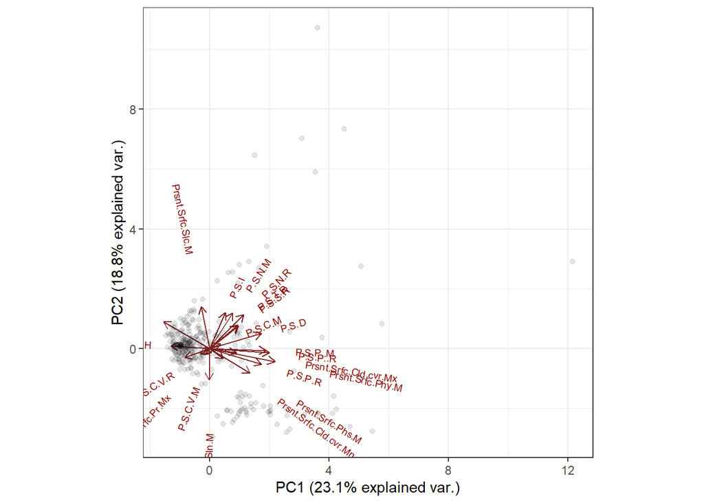

```r
plot(g_PCA_1)
```